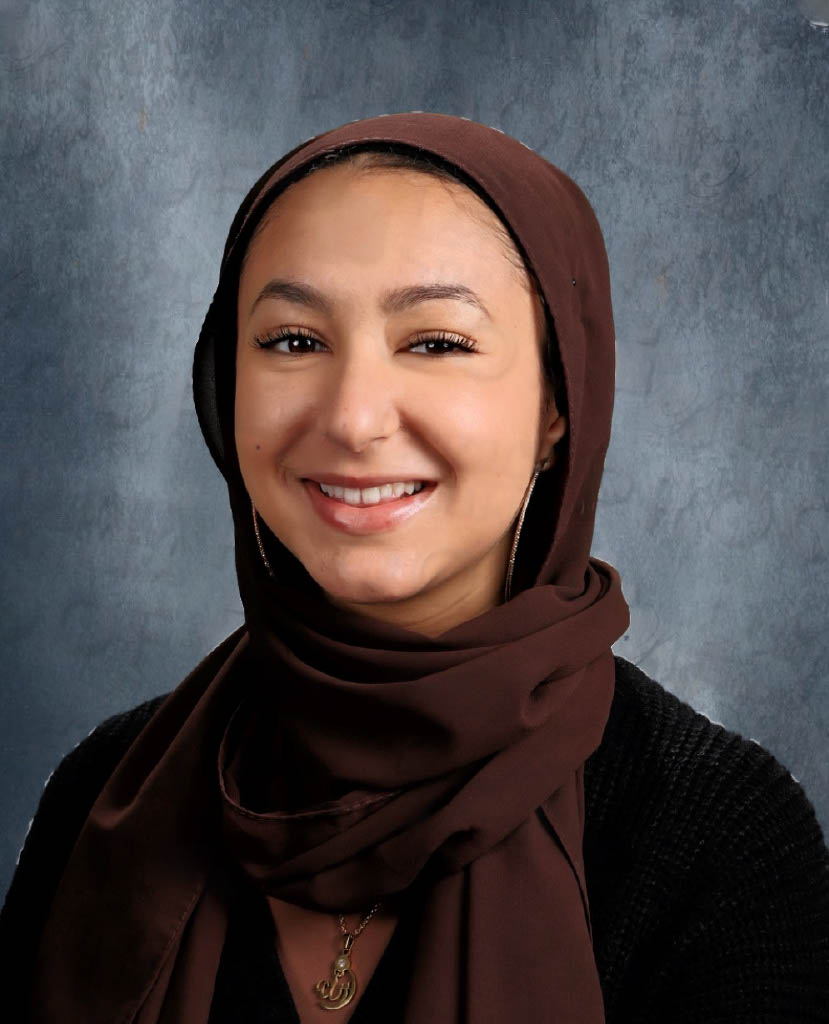

# Nora Elhaissouni

## Bio

Nora Elhaissouni graduated from Tufts University with her Bachelor of Science in May 2023. She is currently a second-year ScM in Biostatistics candidate at The Johns Hopkins Bloomberg School of Public Health and is simultaneously working as a Data Analyst for a pediatric infectious disease research group through the Johns Hopkins Hospital. She is passionate about leveraging data analysis, statistical methods, and quantitative techniques to make evidence-based insights. Her goals are to apply these skills and present them using data visualizations to make meaningful contributions to the public health field. She hopes to gain more research or industry experience and is looking for a full time position upon graduating in May 2025. With a full-time position she hopes to progress her data analysis skills and gain exposure to more fields of applied biostatistics.

## Education

**Johns Hopkins Bloomberg School of Public Health** | Baltimore, MD  
ScM in Biostatistics | August 2023 - May 2025

**Tufts University** | Medford, MA  
B.S. in Biology and Child Development | August 2019 - May 2023

## Experience

##### Johns Hopkins Medicine Data Analyst

**Pediatric Infectious Disease Data Analyst for Dr. Aaron Milstone’s Research Team** | April 2024 – Present  
- **Late-Onset Hospital-Acquired *S. aureus* Project**: Analyzed data from 315 NICUs to estimate *S. aureus* incidence and attributable mortality, using case-control matching and cluster bootstrap techniques. - **BrighT STAR Initiative**: Evaluated quality improvement interventions aimed at reducing antibiotic use in children’s hospitals. - Conducted statistical analyses using R and STATA.

##### Bloomberg School of Public Health Graduate Teaching Assistant

**TA for Statistical Methods in Public Health Sequence** | August 2024 - Present  
- Provided support in statistical concepts, hosted office hours, and assisted with course materials in R Studio.

##### Columbia Mailman School of Public Health Summer Internship

**Biostatistics and Epidemiology Research Assistant** | June 2022 – July 2022  
- Analyzed Adolescent Brain Cognitive Disorder Study (ABCD) data, presented research findings at a symposium, and engaged in professional development seminars.

##### Duke Clinical Research Institute & North Carolina State University Research

**Biostatistics Mentored Research** | May 2021 – August 2021  
- Conducted research on HIV treatment plans using survival analysis, Kaplan-Meier curves, and lasso regression in R.

##### Tufts University Undergraduate Admissions Internship

**Student Intern** | June 2021 - July 2023  
- Supported admissions outreach and provided visitor information to assist recruitment strategies.